# Spaceship Titanic Project

The objective of this project is to conduct an exploratory data analysis of the Spaceship Titanic data set using statistics summary and visualization approaches to explore the data and to identify interesting patterns and significant information within the data.

## Check data structure

```
'data.frame':   8693 obs. of  14 variables:
 $ PassengerId : chr  "0001_01" "0002_01" "0003_01" "0003_02" ...
 $ HomePlanet  : chr  "Europa" "Earth" "Europa" "Europa" ...
 $ CryoSleep   : chr  "False" "False" "False" "False" ...
 $ Cabin       : chr  "B/0/P" "F/0/S" "A/0/S" "A/0/S" ...
 $ Destination : chr  "TRAPPIST-1e" "TRAPPIST-1e" "TRAPPIST-1e" "TRAPPIST-1e" ...
 $ Age         : num  39 24 58 33 16 44 26 28 35 14 ...
 $ VIP         : chr  "False" "False" "True" "False" ...
 $ RoomService : num  0 109 43 0 303 0 42 0 0 0 ...
 $ FoodCourt   : num  0 9 3576 1283 70 ...
 $ ShoppingMall: num  0 25 0 371 151 0 3 0 17 0 ...
 $ Spa         : num  0 549 6715 3329 565 ...
 $ VRDeck      : num  0 44 49 193 2 0 0 NA 0 0 ...
 $ Name        : chr  "Maham Ofracculy" "Juanna Vines" "Altark Susent" "Solam Susent" ...
 $ Transported : chr  "False" "True" "False" "False" ...
```

## Getting insights from the variables

### 1. Where were the home planets of the passengers departed from?

The passengers departed from three main home planets Earth, Europa, and Mars. About half of those passengers (53%) were from Earth. There’re small number (2%) of passengers whose their home planets information are missing.

#### Passenger count by HomePlanet:

```
HomePlanet Count Total %
   Earth    4602      53
   Europa   2131      25
   Mars     1759      20
   Unknown   201       2
   Sum      8693     100
```

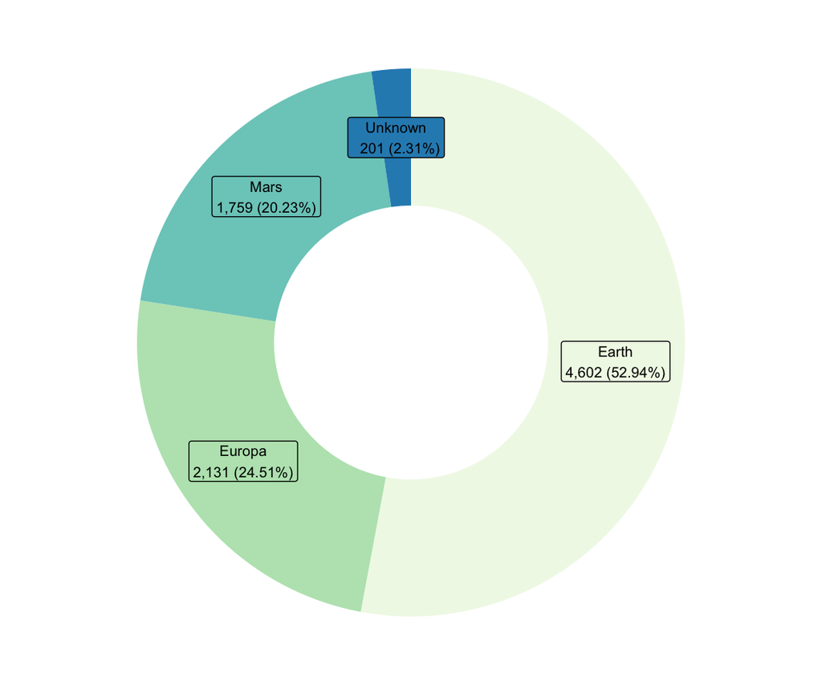

### 2. Which planet destination most passengers would be debarking to?

There are three destinations the passengers would be debarking to 55 Cancri e, PSO J318.5-22, and TRAPPIST-1e. TRAPPIST-1e appears to be the top destination; 68% of the passengers were to emigrate there.

#### Passenger count by Destination:

```
Destination     Count Total %
  55 Cancri e    1800      21
  PSO J318.5-22   796       9
  TRAPPIST-1e    5915      68
  Unknown         182       2
  Sum            8693     100
```

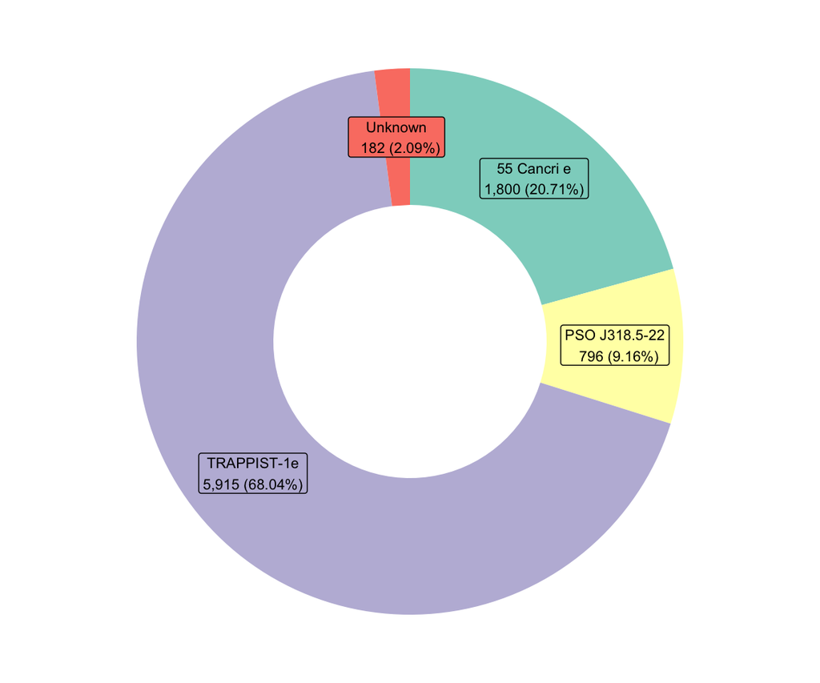

### 3. Top 3 HomePlanet and Destination pairs

The majority of passengers were emigrating from Earth to TRAPPIST-1e (36% of the passengers). The 2nd and 3rd were Mars to TRAPPIST-1e and Europa to TRAPPIST-1e respectively. Though, there were higher number of passengers from Earth who were being transported to TRAPPIST-1e, those from Mars shows higher likelihood to emigrate to TRAPPIST-1e than Earth passengers (84% of passengers from Mars opted to emigrate to TRAPPIST-1e vs. 67% of those from Earth). Passengers from Europa were the only group that shows most interest in emigrating to 55 Cancri e (42% of Europa Passengers were heading there). PSO J318.5-22 appears to be the least appealing destination among the passengers.

#### **HomePlanet & Destination pairs (count):**

```
   HomePlanet   Destination    n percent_total
1       Earth   TRAPPIST-1e 3101            36
2        Mars   TRAPPIST-1e 1475            17
3      Europa   TRAPPIST-1e 1189            14
4      Europa   55 Cancri e  886            10
5       Earth PSO J318.5-22  712             8
6       Earth   55 Cancri e  690             8
7        Mars   55 Cancri e  193             2
8     Unknown   TRAPPIST-1e  150             2
9       Earth       Unknown   99             1
10       Mars PSO J318.5-22   49             1
11       Mars       Unknown   42             0
12     Europa       Unknown   37             0
13    Unknown   55 Cancri e   31             0
14     Europa PSO J318.5-22   19             0
15    Unknown PSO J318.5-22   16             0
16    Unknown       Unknown    4             0
```

#### **Crosstab of HomePlanet & Destination (row %):**

```
           Destination 55 Cancri e PSO J318.5-22 TRAPPIST-1e Unknown    Sum
HomePlanet
Earth                        14.99         15.47       67.38    2.15 100.00
Europa                       41.58          0.89       55.80    1.74 100.00
Mars                         10.97          2.79       83.85    2.39 100.00
Unknown                      15.42          7.96       74.63    1.99 100.00
```

### 4. Who got transported based on HomePlanet and Destination?

Despite the higher number of passengers from Earth on board comparing to the other two home planets, there was a higher percentage among passengers from Europa who got transported (66% of passengers from Europa were transported vs. 42% of passengers from Earth). Home planet Earth appears to have a higher likelihood of those passengers who were not transported.

Passengers of 55 Cancri e destination show the highest portion of being transported (61% of passengers got transported comparing to 47% of those with TRAPPIST-1e destination).

#### Crosstab of HomePlanet & Transported:

```
                       Count      Row %
           Transported False True False True
HomePlanet
Earth                   2651 1951    58   42
Europa                   727 1404    34   66
Mars                     839  920    48   52
Unknown                   98  103    49   51
```

#### Crosstab of Destination & Transported:

```
                          Count      Row %
              Transported False True False True
Destination
55 Cancri e                 702 1098    39   61
PSO J318.5-22               395  401    50   50
TRAPPIST-1e                3128 2787    53   47
Unknown                      90   92    49   51
```

#### Transported passengers by HomePlanet and Destination:

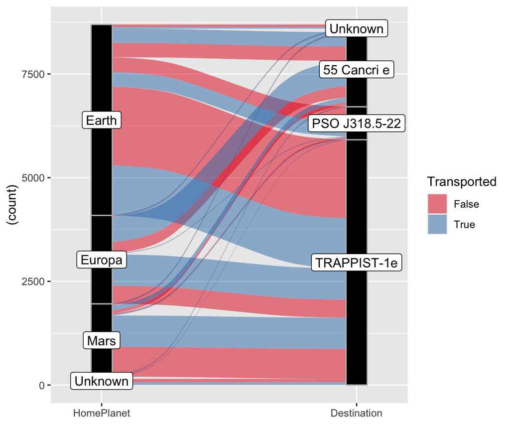

### 5. What did the age groups look like among the passengers?

Average age of the passengers were 29, youngest passengers were 0 (assuming they were newborns who hadn’t reach 1 year old), and the oldest passengers were 79. The majority of the passengers (53%) were adult between 20-39. There were much smaller passengers among those children 0-12 (9%) and senior 60+ (3%).

Among the transported passengers, children 0-12 shows the highest likelihood of being transported (70%) than the older age groups.

#### Summary statistics (Age):

```
   Min. 1st Qu.  Median    Mean 3rd Qu.    Max.    NA's
   0.00   19.00   27.00   28.83   38.00   79.00     179
```

#### Age distribution of the passengers:

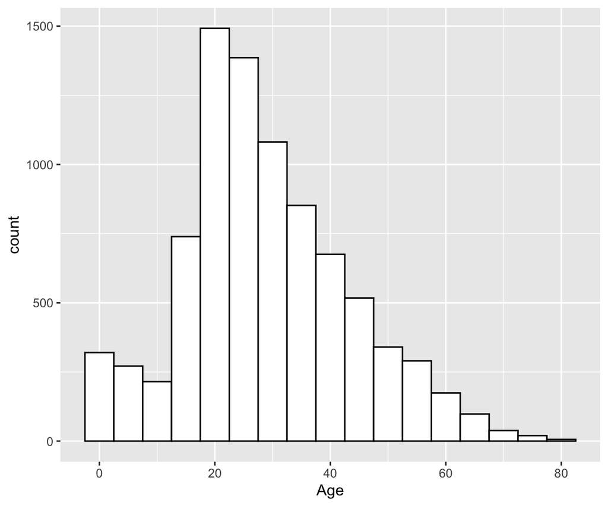

#### Age group (count):

```
Age_group       Count Total %
  Children 0-12   806       9
  Teen 13-19     1352      16
  Adult 20-39    4497      53
  Adult 40-59    1605      19
  Senior 60+      254       3
  Sum            8514     100
```

#### Crosstab of Age group & Transported:

```
                          Count           Row %
              Transported False True  Sum False True  Sum
Age_group
Children 0-12               242  564  806    30   70  100
Teen 13-19                  645  707 1352    48   52  100
Adult 20-39                2405 2092 4497    53   47  100
Adult 40-59                 799  806 1605    50   50  100
Senior 60+                  135  119  254    53   47  100
```

#### Age distribution of the passengers by Transported groups:

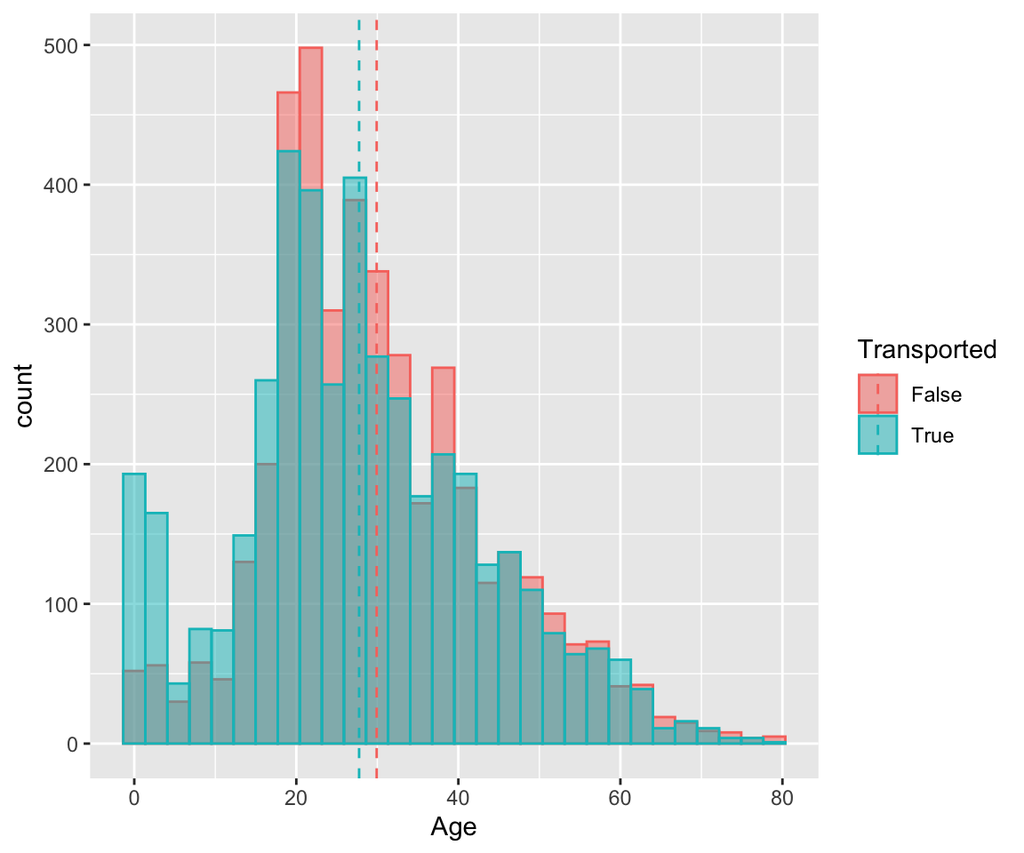

### 6. Who used CryoSleep during the voyage?

More passengers (64%) opted to not be put into CryoSleep. Younger passengers (children 0-12 and teens 13-19) appears to have slightly higher percentage to use CryoSleep than older groups. There’s significant percentage indicating those who opted to use CryoSleep had a higher chance (82%) being transported comparing to those who didn’t opt CryoSleep with more likelihood 67% for not being transported.

#### Passenger opting CryoSleep (count):

```
CryoSleep Count Total %
    False  5439      64
    True   3037      36
    Sum    8476     100
```

#### CryoSleep vs Avg passenger age:

```
# A tibble: 3 × 2
  CryoSleep Avg_age
  <chr>       <dbl>
1 False          30
2 True           27
3 <NA>           28
```

#### Crosstab of Age group & CryoSleep:

```
                        Count           Row %
              CryoSleep False True  Sum False True  Sum
Age_group
Children 0-12             406  377  783    52   48  100
Teen 13-19                758  555 1313    58   42  100
Adult 20-39              2973 1416 4389    68   32  100
Adult 40-59              1042  524 1566    67   33  100
Senior 60+                164   83  247    66   34  100
```

#### Crosstab of CryoSleep & Transported:

```
                      Count           Row %
          Transported False True  Sum False True  Sum
CryoSleep
False                  3650 1789 5439    67   33  100
True                    554 2483 3037    18   82  100
```

#### Passengers in cryosleep vs Transported:

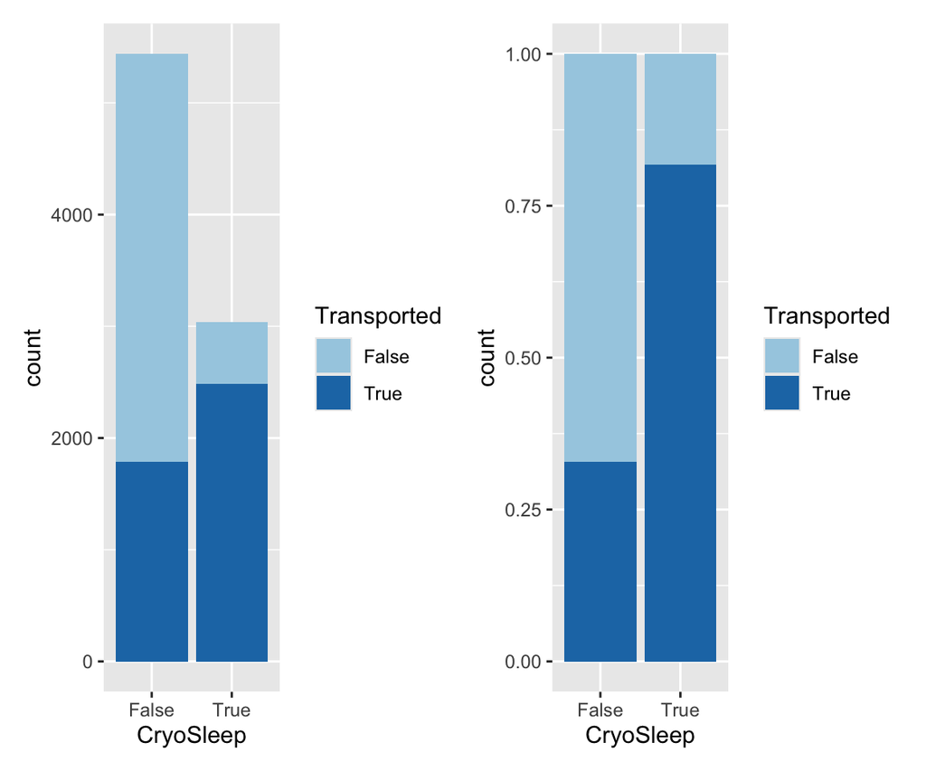

#### Count of passengers opting CryoSleep by HomePlanet and Destination:

```
 HomePlanet 55 Cancri e PSO J318.5-22 TRAPPIST-1e Unknown Total
      Earth         205           355         809      13  1382
     Europa         441             9         447      14   911
       Mars          76            11         561      21   669
    Unknown          17             8          50       0    75
      Total         739           383        1867      48  3037
```

### 7. Who were those VIP passengers? Did many of them get transported?

There was only a small group (2%) of the passengers who paid for VIP service during the voyage. Among those VIP passengers were adult and senior age groups. Interestingly, there were no passengers from Earth paid for VIP - only those from Europa and Mars paid for the service.

More than half (62%) of those VIP passengers didn’t get transported to their destination.

#### VIP passengers (count):

```
VIP     Count Total %
  False  8291      98
  True    199       2
  Sum    8490     100
```

#### VIP passengers vs Avg age:

```
# A tibble: 3 × 2
  VIP   Avg_age
  <chr>   <dbl>
1 False      29
2 True       37
3 <NA>       28
```

#### VIP passengers vs Age group:

```
                  Count           Row %
              VIP False True  Sum False True  Sum
Age_group
Children 0-12       782    0  782   100    0  100
Teen 13-19         1317    2 1319   100    0  100
Adult 20-39        4270  131 4401    97    3  100
Adult 40-59        1515   54 1569    97    3  100
Senior 60+          235   11  246    96    4  100
```

#### VIP passengers vs Transported:

```
                  Count           Row %
      Transported False True  Sum False True  Sum
VIP
False              4093 4198 8291    49   51  100
True                123   76  199    62   38  100
```

#### Count of VIP passengers by HomePlanet and Destination (% column):

```
 HomePlanet 55 Cancri e PSO J318.5-22  TRAPPIST-1e    Unknown        Total
     Europa  96.9% (63)    55.6% (10)  49.1%  (56) 100.0% (2)  65.8% (131)
       Mars   0.0%  (0)    44.4%  (8)  48.2%  (55)   0.0% (0)  31.7%  (63)
    Unknown   3.1%  (2)     0.0%  (0)   2.6%   (3)   0.0% (0)   2.5%   (5)
      Total 100.0% (65)   100.0% (18) 100.0% (114) 100.0% (2) 100.0% (199)
```

#### VIP passengers vs Transported:

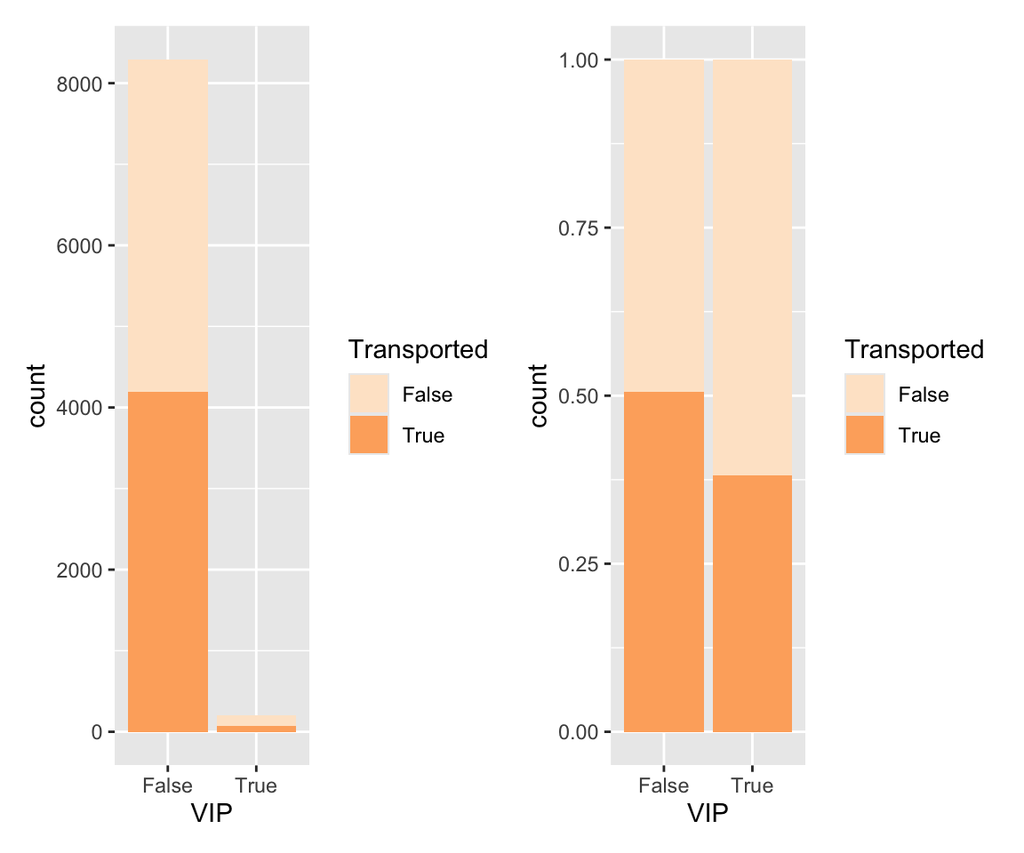

### 8. Who were those big spenders on board?

#### Top 5 spenders by Total bill:

```
                Name Age HomePlanet Destination   VIP Transported Total_bill
1  Markar Radisiouss  68     Europa 55 Cancri e False       False      35987
2 Pulchib Quidedbolt  41     Europa 55 Cancri e  True        True      31076
3     Scharab Conale  31     Europa 55 Cancri e  True        True      31074
4   Mirfar Optionful  18     Europa TRAPPIST-1e False       False      30478
5     Maiam Oilloody  36     Europa 55 Cancri e False       False      29608
```

#### Sum of Total bill by HomePlanet:

```
# A tibble: 4 × 2
  HomePlanet Sum_Total_bill
  <chr>               <dbl>
1 Europa            6828385
2 Earth             2823306
3 Mars              1696039
4 Unknown            209893
```

#### Average Total bill by HomePlanet:

```
# A tibble: 4 × 2
  HomePlanet Avg_Total_bill
  <chr>               <dbl>
1 Europa              3553.
2 Unknown             1147.
3 Mars                1074.
4 Earth                688.
```

#### Boxplot of HomePlanet vs Total bill:

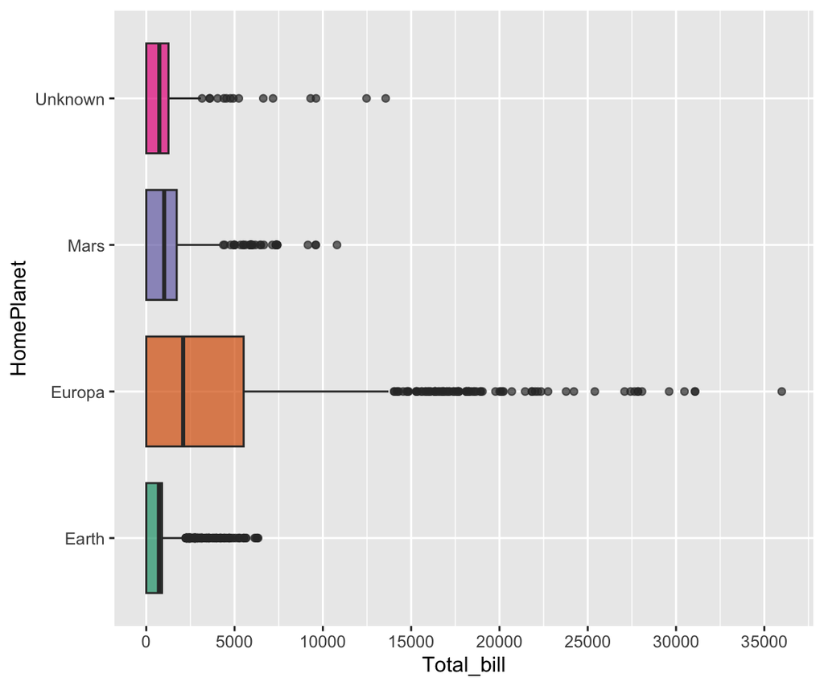

#### Sum of Total bill by Destination:

```
# A tibble: 4 × 2
  Destination   Sum_Total_bill
  <chr>                  <dbl>
1 TRAPPIST-1e          7316054
2 55 Cancri e          3606677
3 PSO J318.5-22         416911
4 Unknown               217981
```

#### Average Total bill by Destination:

```
# A tibble: 4 × 2
  Destination   Avg_Total_bill
  <chr>                  <dbl>
1 55 Cancri e            2235.
2 TRAPPIST-1e            1382.
3 Unknown                1337.
4 PSO J318.5-22           582.
```

#### Sum of Total bill by Age group:

```
# A tibble: 6 × 2
  Age_group     Sum_Total_bill
  <fct>                  <dbl>
1 Adult 20-39          6896604
2 Adult 40-59          2841561
3 Teen 13-19           1154290
4 Senior 60+            460733
5 <NA>                  204435
6 Children 0-12              0
```

#### Average Total bill by Age group:

```
# A tibble: 6 × 2
  Age_group     Avg_Total_bill
  <fct>                  <dbl>
1 Senior 60+             2012.
2 Adult 40-59            1971.
3 Adult 20-39            1717.
4 <NA>                   1239
5 Teen 13-19              952.
6 Children 0-12             0
```

#### Boxplot of Age group vs Total bill:

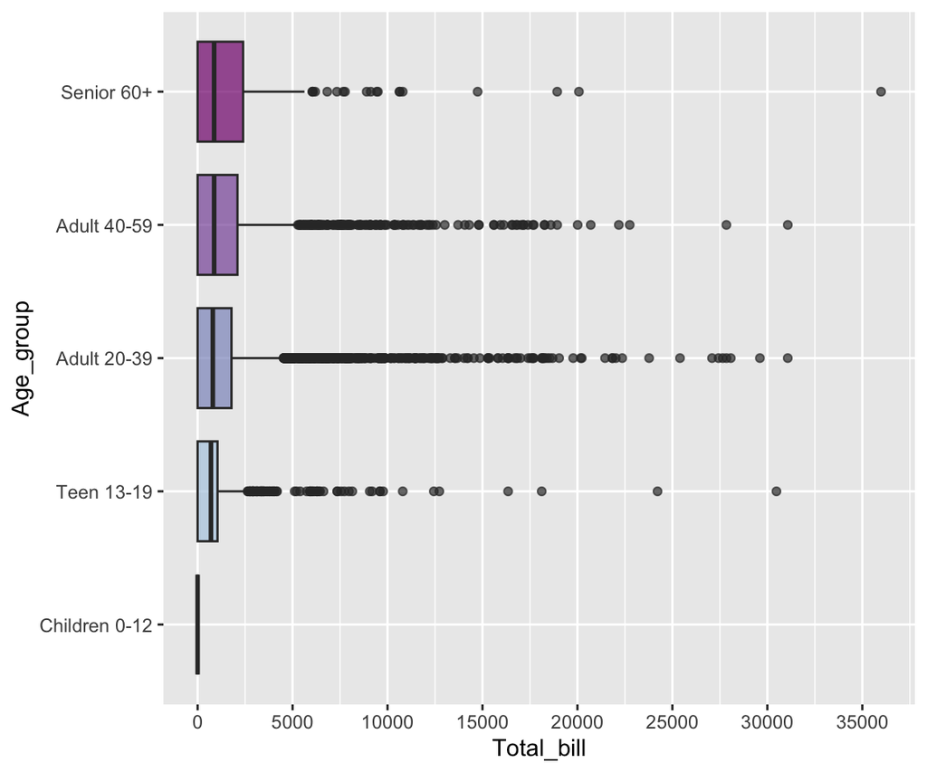

#### Sum of Total bill by Transported:

```
# A tibble: 2 × 2
  Transported Sum_Total_bill
  <chr>                <dbl>
1 False              7938955
2 True               3618668
```

#### Boxplot of Transported vs Total bill:

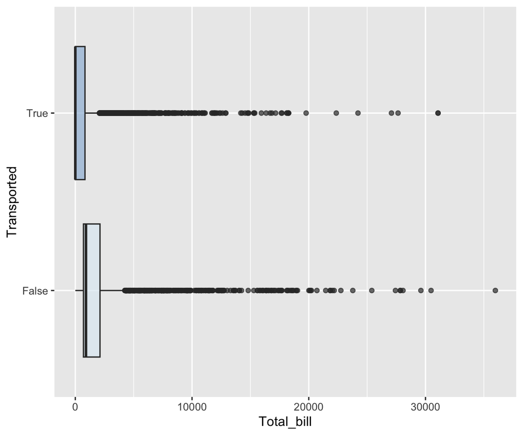

### 9. How many passengers got transported?

#### Passengers count by Transported:

```
Transported  Count Total %
      False 4315.0    49.6
      True  4378.0    50.4
      Sum   8693.0   100.0
```

## Conclusion

The Spaceship Titanic data has records of 8,693 passengers (observations) who were on the spaceship emigrating to new habitable planets. The dataset collects the passenger information including their Name, HomePlanet, Destination, Age, amenity usage like CryoSleep, their spending on luxury amenities, VIP status, and whether they were transported to another dimension.

After analyzing the data, it was found that the passengers were from Earth, Europa, and Mars emigrating to these three new destinations 55 Cancri e, PSO J318.5-22, and TRAPPIST-1e. Earth passengers were the largest group among all passengers (4,602 / 53%). TRAPPIST-1e was the destination where the majority of the passengers were debarking to (5,915 / 68%). The passenger age ranges from youngest (less than 1 year old) to oldest 79 years old. The largest age group were those adult age 20-39 (4,497 / 53%). More passengers (5,439 / 64%) opted to not be put into CryoSleep for the duration of the voyage. There was very small group of passengers (199 / 2%) who paid for VIP service. The passengers from Europa were dominating the VIP service and they were also the biggest spenders on the luxury amenities.